# Questionnaire e-TAC sur le Travail collectif et outils numériques en milieu scolaire: présentation des questions

# E. Les outils du travail en classe

# 29)* En classe, je dispose de :

Parmi les 972 enseignants ayant répondu à l’ensemble du questionnaire, 178 (18.3%) disposent de matériel expérimental (ex : sciences et technologies) en classe.

| *En classe, je dispose de:* `NumClMat` | Effectif au collège | Effectif en élémentaire | % au collège | % en élémentaire | % Global |
| --- | --- | --- | --- | --- | --- |
| tableau noir et craies `ClTabNoir` | 114 | 279 | 19.8 | 70.3 | 40.4 |
| tableau blanc et feutres effaçables `ClTabBlc` | 493 | 275 | 85.7 | 69.3 | 79 |
| matériel expérimental (ex : sciences et technologies) `ClMatExp` | 87 | 91 | 15.1 | 22.9 | 18.3 |
| outils numériques `ClMatNum.reg` | 500 | 339 | 87 | 85.4 | 86.3 |
| accès internet `ClNet` | 446 | 283 | 77.6 | 71.3 | 75 |
| tableau numérique interactif (TNI, TBI, VPI) `ClTNI` | 182 | 159 | 31.7 | 40.1 | 35.1 |
| vidéoprojecteur `ClVideoProj` | 351 | 167 | 61 | 42.1 | 53.3 |
| chariot mobile `ClCharMob` | 22 | 18 | 3.8 | 4.5 | 4.1 |
| ordinateurs `ClOrdi` | 241 | 226 | 41.9 | 56.9 | 48 |
| tablettes `ClTab` | 72 | 41 | 12.5 | 10.3 | 11.6 |
| je peux accéder à une salle informatique dédiée `ClSalleInfo` | 299 | 132 | 52 | 33.2 | 44.3 |
| autres outils `Clother` | 52 | 32 | 9 | 8.1 | 8.6 |
| TOTAL | 575 | 397 |  |  | n =972 |

`ClTabNoir` (p 1.810^{-53}%) `ClTabBlc` (p 9.510^{-8}%) `ClMatExp` (p 0.3%) `ClNet` (p 2.1%) `ClTNI` (p 0.3%) `ClVideoProj` (p 1.410^{-7}%) `ClCharMob` (p 65.9%) `ClOrdi` (p 1.910^{-5}%) `ClTab` (p 39.2%) `ClSalleInfo` (p 1.110^{-6}%) `Clother` (p 67.4%)

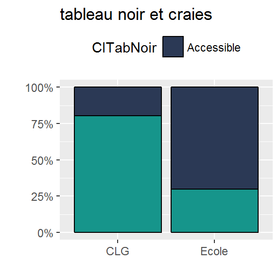

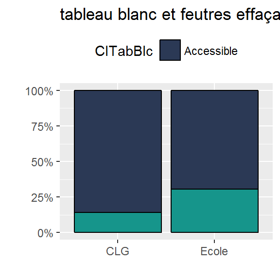

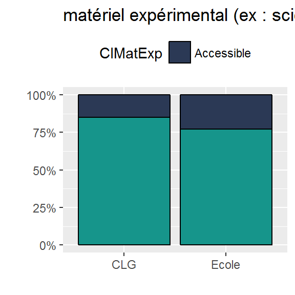

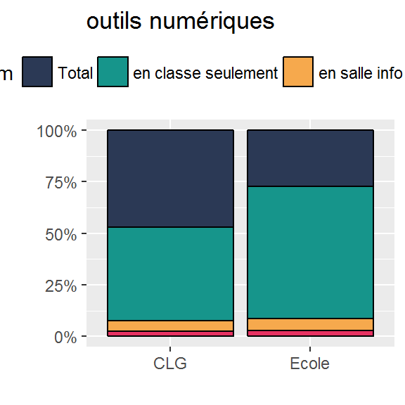

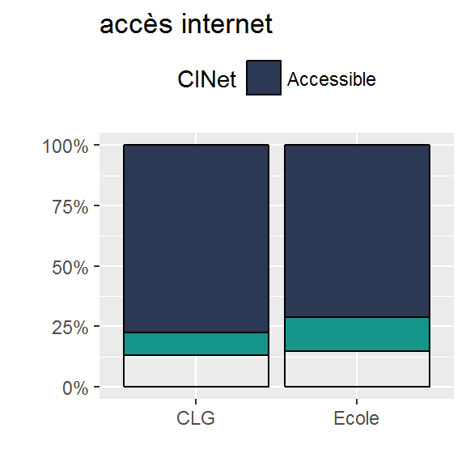

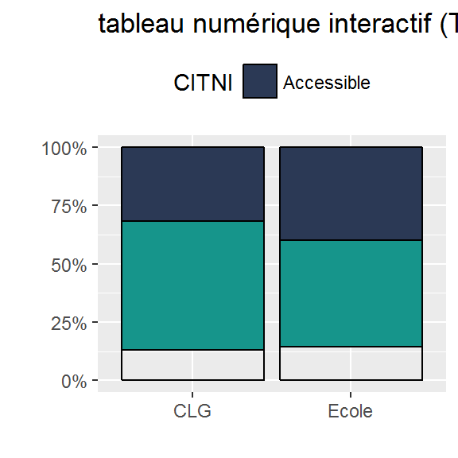

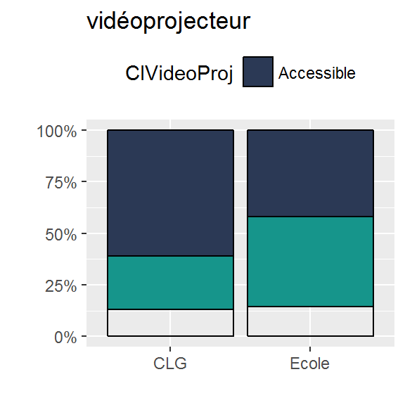

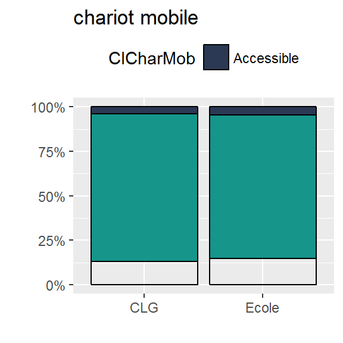

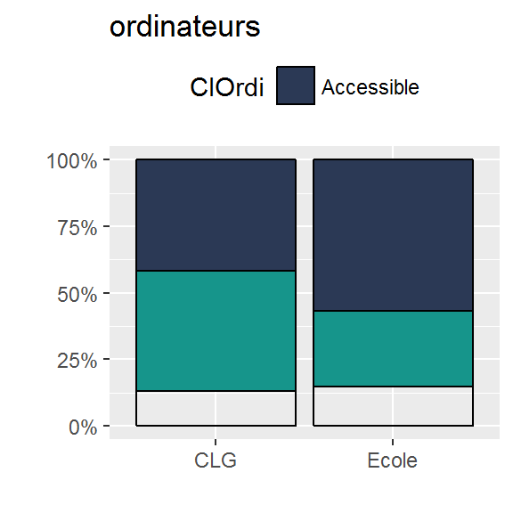

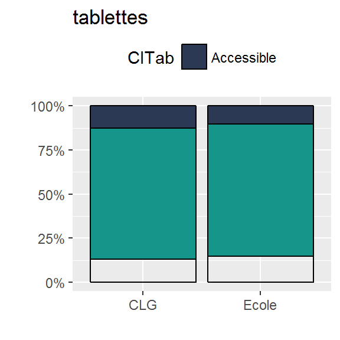

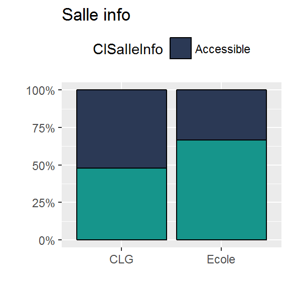

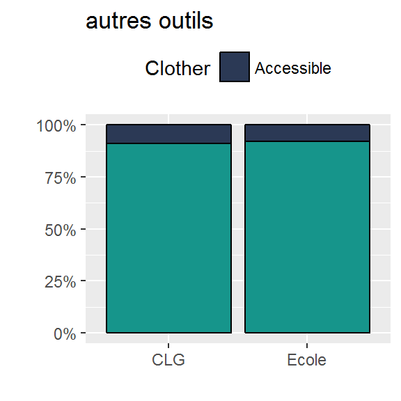

# 30) En classe, je mets ces outils à disposition des élèves pour travailler en groupe:

`NumClMatUse`

# 31) Selon vous, quel est le nombre idéal d’élèves par outil numérique pour le travail en groupe?

## par ordinateur en classe: n élèves

`NbEOrdiCl`

`NbEOrdiCl.reg` (p 7.8%)

|  | #Total | CLG | Ecole |
| --- | --- | --- | --- |
| dH$NbEOrdiCl.reg |  |  |  |
| 2 | 73 | 79.9 | 66.7 |
| 3 | 16.3 | 10.1 | 22 |
| 4 | 4.8 | 5 | 4.7 |
| 5 | 2.4 | 2.2 | 2.7 |
| plus de 5 | 3.5 | 2.9 | 4 |
| #Total cases | 289 | 139 | 150 |

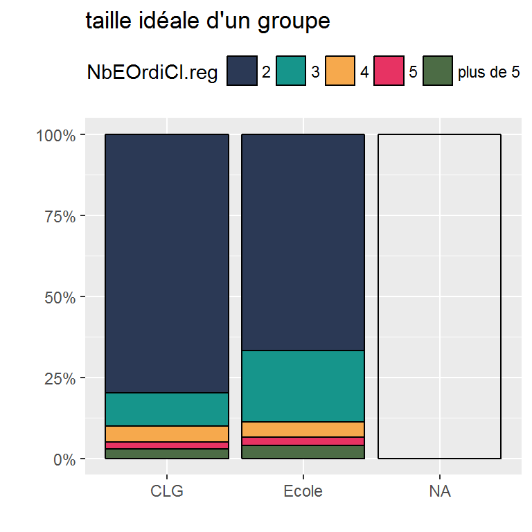

## par tablette: n élèves

`NbETab`

`NbETab.reg` (p 62.1%)

|  | #Total | CLG | Ecole |
| --- | --- | --- | --- |
| dH$NbETab.reg |  |  |  |
| 2 | 70.5 | 66.1 | 79.3 |
| 3 | 14.8 | 15.3 | 13.8 |
| 4 | 9.1 | 11.9 | 3.4 |
| 5 | 1.1 | 1.7 |  |
| plus de 5 | 4.5 | 5.1 | 3.4 |
| #Total cases | 88 | 59 | 29 |

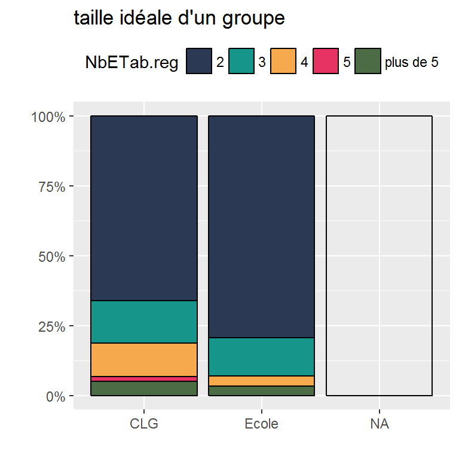

## par ordinateur en salle informatique: n élèves

`NbEOrdiSI`

`NbEOrdiSI.reg` (p 40.9%)

|  | #Total | CLG | Ecole |
| --- | --- | --- | --- |
| dH$NbEOrdiSI.reg |  |  |  |
| 2 | 85.4 | 84.6 | 87.1 |
| 3 | 7.5 | 6.5 | 10 |
| 4 | 1.7 | 2.4 |  |
| 5 | 0.8 | 1.2 |  |
| plus de 5 | 4.6 | 5.3 | 2.9 |
| #Total cases | 239 | 169 | 70 |

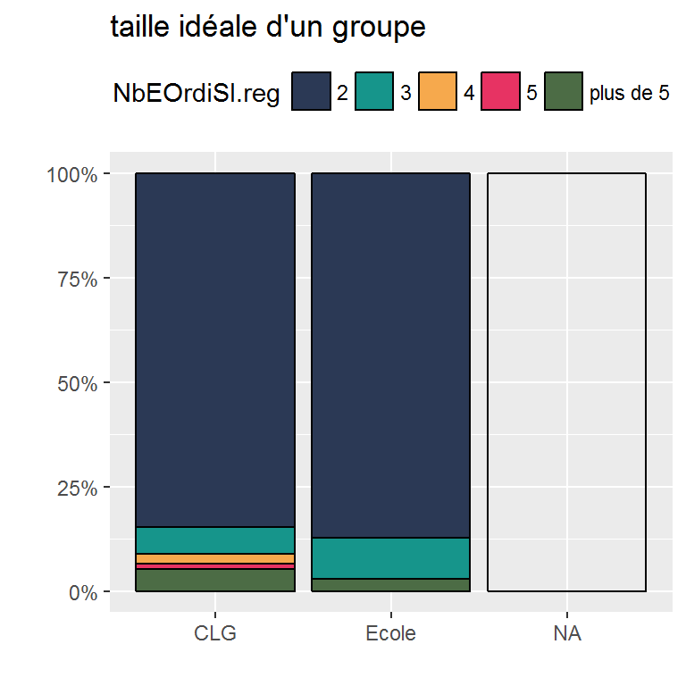

# 32) En classe, je mets ces ressources à disposition des élèves pour travailler en groupe :

## Ressources numériques

`ClNumDoc` (p NaN%)

|  | #Total | CLG | Ecole |
| --- | --- | --- | --- |
| dH$ClNumDoc |  |  |  |
| Aucune ressource numérique | 51.5 | 45.8 | 60.1 |
| ressources API seulement |  |  |  |
| ressources ENT seulement | 9.8 | 14.7 | 2.4 |
| ressources web seulement | 21.7 | 13.5 | 33.9 |
| ressources web & API |  |  |  |
| ressources ENT & API | 2 | 3.3 |  |
| ressources web & ENT | 12.2 | 18.6 | 2.6 |
| Toutes ressources numériques | 2.8 | 4 | 1 |
| #Total cases | 951 | 570 | 381 |

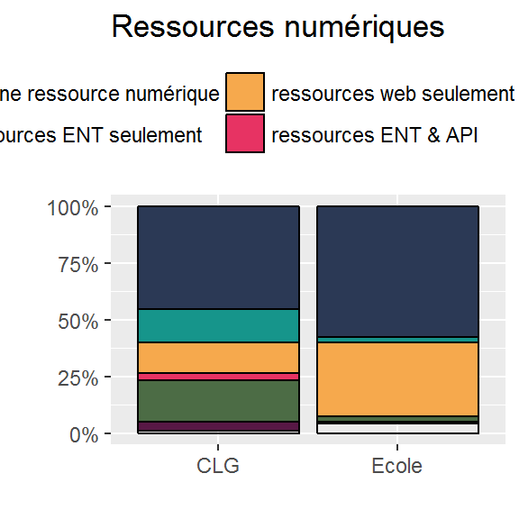

## Ressources papier

`ClPDoc` (p 3.210^{-30}%)

|  | #Total | CLG | Ecole |
| --- | --- | --- | --- |
| dH$ClPDoc |  |  |  |
| Aucune ressource papier | 21.8 | 28.9 | 9.6 |
| Livres seulement | 24.3 | 31.2 | 12.2 |
| dictionnaires seulement | 6.2 | 6.8 | 5.2 |
| revues seulement | 2.6 | 4 |  |
| livres et revues | 6.2 | 6.4 | 5.9 |
| dictionnaires et revues | 0.9 | 1.3 | 0.4 |
| Toutes ressources papier | 38 | 21.4 | 66.8 |
| #Total cases | 742 | 471 | 271 |

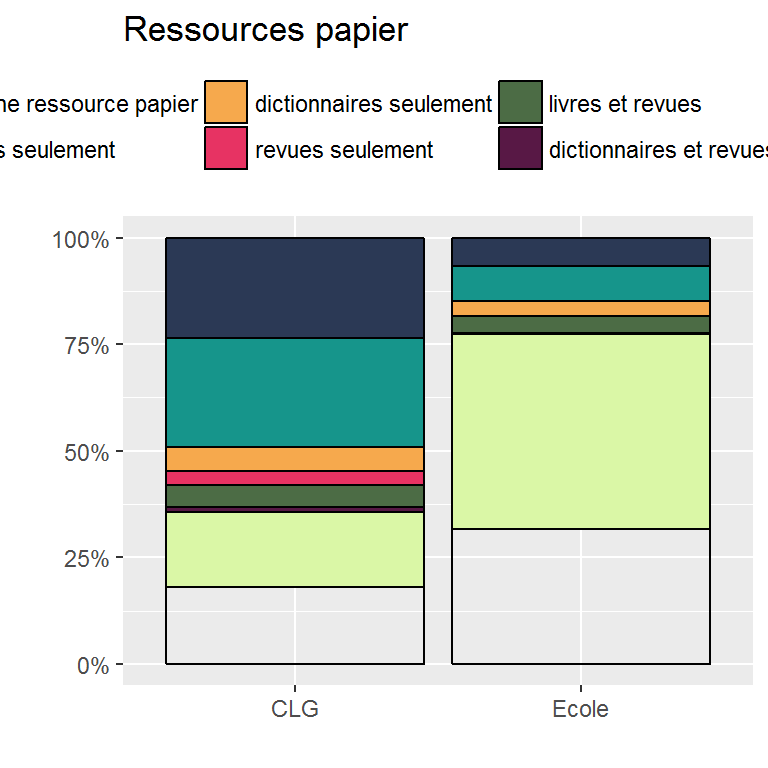

# 33)* En 1h de travail en groupe, mes élèves utilisent ces outils et ressources numériques pendant environ :

Parmi les 461 enseignants ayant validé l’ensemble du questionnaire et mis des ressources numériques à la disposition des élèves pour travailler en groupe, 221 (47.9%) déclarent qu’en 1h de travail en groupe, leurs élèves utilisent ces outils et ressources numériques pendant environ 15 à 30mn

`WEleveGpePcNum` (p 0%)

|  | #Total | CLG | Ecole |
| --- | --- | --- | --- |
| dH$WEleveGpePcNum |  |  |  |
| entre 15 et 30mn. | 47.9 | 45 | 53.9 |
| entre 30 et 45mn. | 16.5 | 19.7 | 9.9 |
| Moins de 15mn. | 31 | 28.5 | 36.2 |
| plus de 45mn. | 4.6 | 6.8 |  |
| #Total cases | 461 | 309 | 152 |

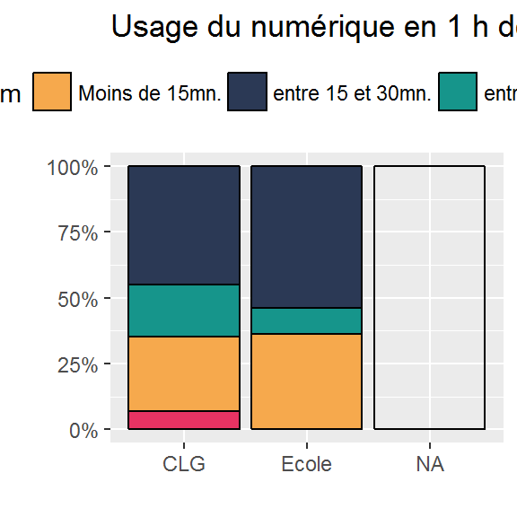

# 34)* Je pense que le travail des élèves avec le numérique est davantage adapté aux activités:

| Adapté aux activités de groupe | CLG | Ecole | % CLG | % Ecole | % Global |
| --- | --- | --- | --- | --- | --- |
| thématiques `ActThema` | 382 | 304 | 66.4 | 76.6 | 70.6 |
| disciplinaires `ActDisc` | 432 | 255 | 75.1 | 64.2 | 70.7 |
| inter-disciplinaires `ActInterDisc` | 272 | 176 | 47.3 | 44.3 | 46.1 |
| inter-classes `ActInterCl` | 100 | 55 | 17.4 | 13.9 | 15.9 |
| inter-établissements `ActInterEtab` | 96 | 51 | 16.7 | 12.8 | 15.1 |
| Total | 575 | 397 |  |  | 972 |

`ActDisc.regNum` (p 0%) `ActThema.regNum` (p 0.1%) `ActInterDisc.regNum` (p 39.6%) `ActInterCl.regNum` (p 16.4%) `ActInterEtab.regNum` (p 12%)

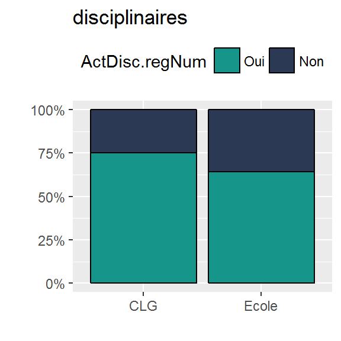

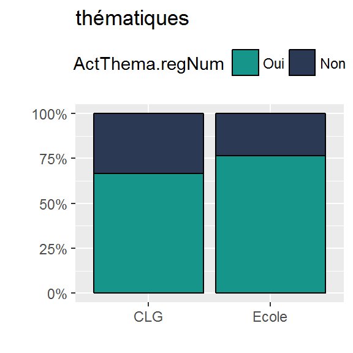

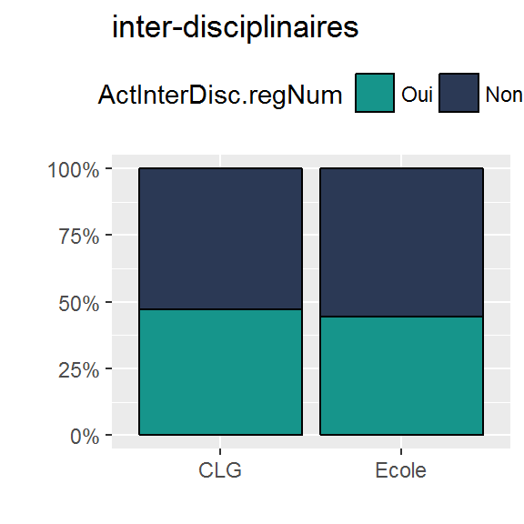

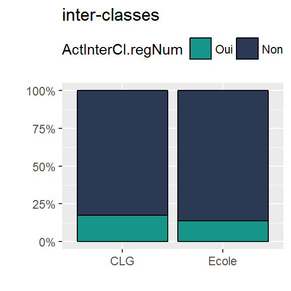

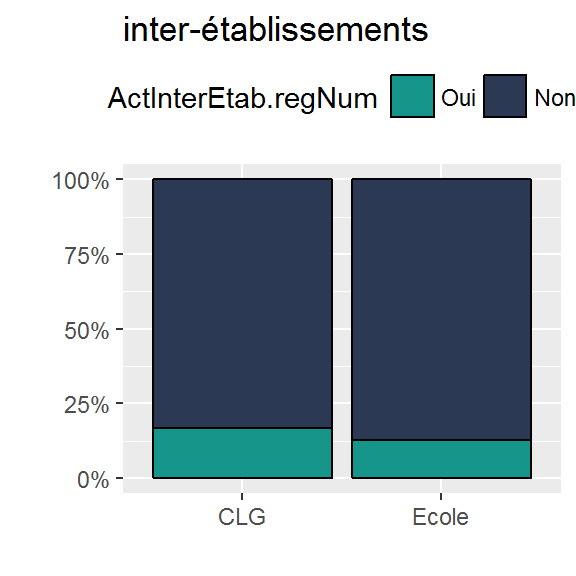

# Q23 & Q34* compilées

Les questions 23 et 34 sont les deux formulations d’une question interrogeant d’abord l’intérêt du travail collectif des élèves (partie D, Q23), puis celui du numérique (partie E, Q34) pour ces cinq types d’activités. A chacune correspond une variable en 4 modalités:  
- “Collectif”“: seul le travail des élèves en groupe est adapté à cette activité  
-”Numérique“: seul le travail des élèves avec le numérique est adapté à cette activité  
-”Collectif & Numérique“: le travail des élèves en groupe et le travail des élèves avec le numérique sont adaptés à cette activité  
- Aucune: ni le travail des élèves en groupe, ni le travail des élèves avec le numérique ne sont adaptés à cette activité

## Collège

Parmi les 575 enseignants des collège ayant validé l’ensemble du questionnaire, 359 (62.4%) pensent que le travail des élèves, d’une part en groupe et d’autre part avec le numérique, est davantage adapté aux activités disciplinaires.

| Activités | Non | Collectives | Numériques | Collectives & Numériques |
| --- | --- | --- | --- | --- |
| thématiques `ActThema` | 25.9 | 7.7 | 11.7 | 54.8 |
| disciplinaires `ActDisc` | 17.2 | 7.7 | 12.7 | 62.4 |
| inter-disciplinaires `ActInterDisc` | 39.7 | 13 | 7.7 | 39.7 |
| inter-classes `ActInterCl` | 75.1 | 7.5 | 5.9 | 11.5 |
| inter-établissements `ActInterEtab` | 79.8 | 3.5 | 4.9 | 11.8 |